```r
# Packages required for Chapter 4
library(gridExtra)
library(knitr)
library(kableExtra)
library(mosaic)
library(xtable)
library(pscl)
library(multcomp)
library(pander)
library(MASS)
library(tidyverse)
```

Exercises 1-4 involve predicting a **response** using one or more **explanatory variables**, where these examples have response variables that are counts per some unit of time or space. List the response (both what is being counted and over what unit of time or space) and relevant explanatory variables.

1. Are the number of motorcycle deaths in a given year related to a state’s helmet laws? The response variable is the count of motorcycle deaths, and the unit of time is a year. The explanatory variable is the state’s helmet law.
2. Does the number of employers conducting on-campus interviews during a year differ for public and private colleges?

The response variable is the count of employers conducting interviews, and the unit of time is a year. The main explanatory variable is the type of college.

3. Does the daily number of asthma-related visits to an Emergency Room differ depending on air pollution indices?

The response variable is the count of visits, and the unit of time is likely a day. The main explanatory variable is the air pollution index.

4. Has the number of deformed fish in randomly selected Minnesota lakes been affected by changes in trace minerals in the water over the last decade?

The response variable is the count of deformed fish, and the unit of time is likely years over the last decade. The main explanatory variable is the changes in trace minerals in the water

5. Models of the form $Y_i=\beta_0+\beta_1X_i+\epsilon_i, \epsilon_i \sim iidN(0,\sigma)$ are fit using the method of least squares. What method is used to fit Poisson regression models?

The method used to fit Poisson regression models is Maximum Likelihood Estimation.

8. Why is the log of mean counts, log($\bar{Y}$), not $\bar{Y}$, plotted against X when assessing the assumptions for Poisson regression?
- Taking the log of the mean counts helps linearize the relationship between the predictor variable and the expected value of the response variable
- stabilizes the variance

Complete (a)-(c) in the context of the study for Exercises 11-13.  
a. Define the response. b. What are the possible values for the response? c. What does $\lambda$ represent?  
11. **Fish (or, as they say in French, poisson).** A state wildlife biologist collected data from 250 park visitors as they left at the end of their stay. Each was asked to report the number of fish they caught during their one-week stay. On average, visitors caught 21.5 fish per week. a. The response is the number of fish caught by each park visitor during their one-week stay.

2. The possible values for the response are unsigned integers.
3. Average number of fish caught per week. In this case, $\lambda$ would be 21.5.

### Guided Exercises

1. **College burglaries.** We wish to build a regression model to describe the number of burglaries on a college campus in a year. Our population of interest will be U.S. liberal arts colleges.
   1. Describe why the response variable ($Y$ = # burglaries on campus in a year) could be modeled by a Poisson distribution.
   2. Describe explanatory variables which might explain differences in $\lambda_i$ = mean number of burglaries per year on campus $i$.
   3. Consider a campus with an average of 5 burglaries per year. Use `dpois()` to sketch a plot of the distribution of $Y$ for this campus. Use `rpois()` to verify that both the mean and variance of $Y$ are given by $\lambda=5$.
   4. Consider a campus with an average of 20 burglaries per year and repeat (c).  
      Answers
- The events are independent of each other.
- The average rate of events (burglaries) occurring in a fixed interval is constant.
- The probability of more than one event occurring in an infinitesimally small interval is negligible.
- Campus security measures.
- Campus location (socioeconomic or urban vs rural(?))
- Student pop
- private or public

c&d.

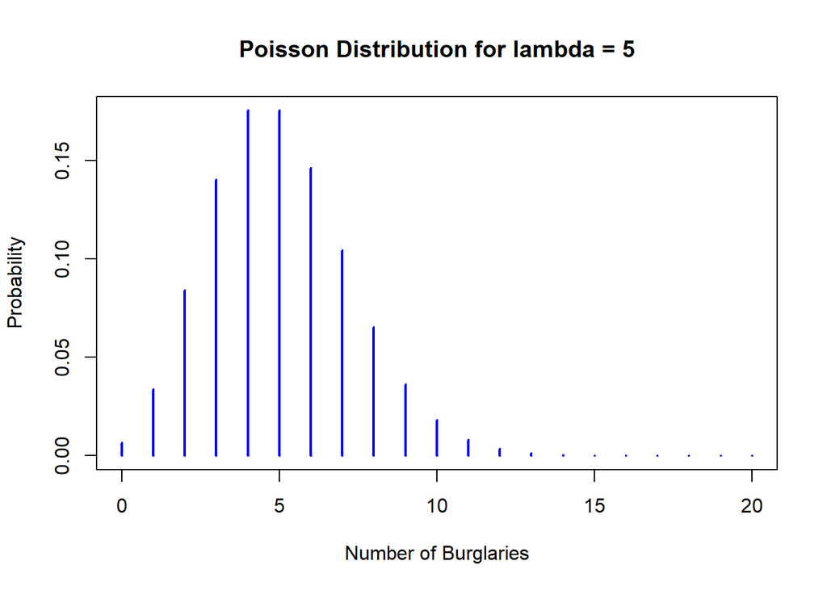

```r
# Plotting the distribution

x <- 0:20
y <- dpois(x, lambda = 5)
plot(x, y, type = "h", lwd = 2, col = "blue", xlab = "Number of Burglaries", ylab = "Probability", main = "Poisson Distribution for lambda = 5")
```

```r
# Verifying mean and variance
mean_y <- mean(rpois(10000, lambda = 5))
var_y <- var(rpois(10000, lambda = 5))
print(paste("Mean of Y:", mean_y))
```

```
## [1] "Mean of Y: 5.0353"
```

```r
print(paste("Variance of Y:", var_y))
```

```
## [1] "Variance of Y: 4.9066596259626"
```

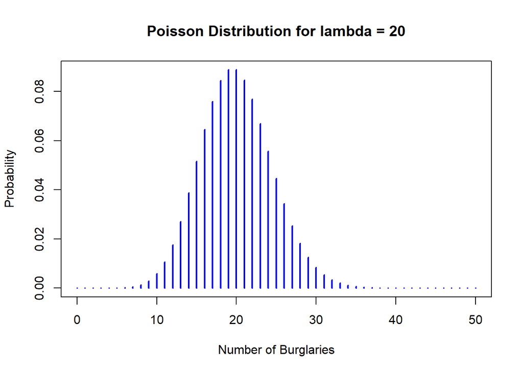

```r
x <- 0:50
y <- dpois(x, lambda = 20)
plot(x, y, type = "h", lwd = 2, col = "blue", xlab = "Number of Burglaries", ylab = "Probability", main = "Poisson Distribution for lambda = 20")
```

```r
# Verifying mean and variance
mean_y <- mean(rpois(10000, lambda = 20))
var_y <- var(rpois(10000, lambda = 20))
print(paste("Mean of Y:", mean_y))
```

```
## [1] "Mean of Y: 19.9659"
```

```r
print(paste("Variance of Y:", var_y))
```

```
## [1] "Variance of Y: 20.6352756875688"
```

2. **Elephant mating.** How does age affect male elephant mating patterns? An article by @Poole1989 investigated whether mating success in male elephants increases with age and whether there is a peak age for mating success. To address this question, the research team followed 41 elephants for one year and recorded both their ages and their number of matings. The data [@Ramsey2002] is found in `elephant.csv`, and the variables are:
   - `MATINGS` = the number of matings in a given year
   - `AGE` = the age of the elephant in years.

```r
elephant <- read.csv("data/elephant.csv")
```

```
a. Create a histogram of MATINGS. Is there preliminary evidence that number of matings could be modeled as a Poisson response? Explain.
```

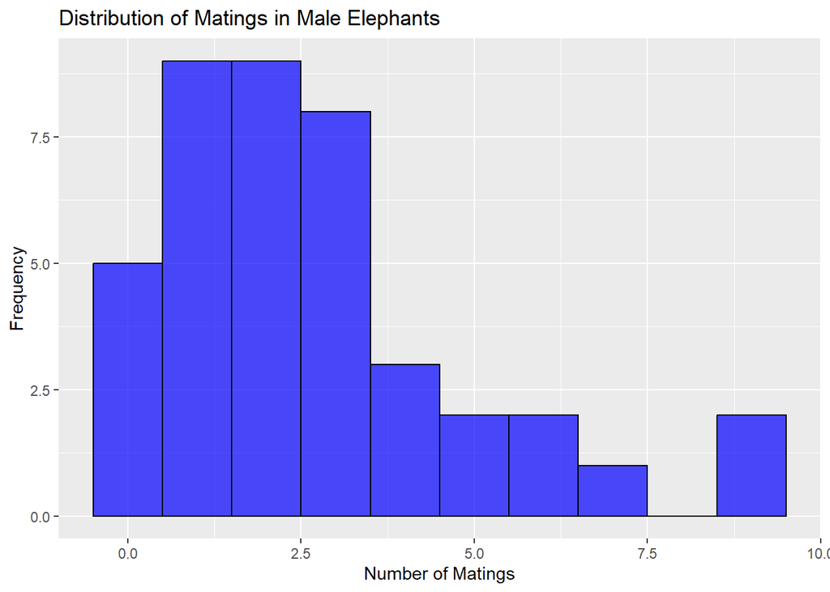

```r
ggplot(elephant, aes(x = MATINGS)) +
  geom_histogram(binwidth = 1, fill = "blue", color = "black", alpha = 0.7) +
  labs(title = "Distribution of Matings in Male Elephants",
       x = "Number of Matings",
       y = "Frequency")
```

Yes. This is a right skewed distribution with one hump. This looks like what we are looking for for modeling poisson.

```
b. Plot MATINGS by AGE. Add a least squares line. Is there evidence that modeling matings using a linear regression with age might not be appropriate? Explain.  (Hints: fit a smoother; check residual plots).
```

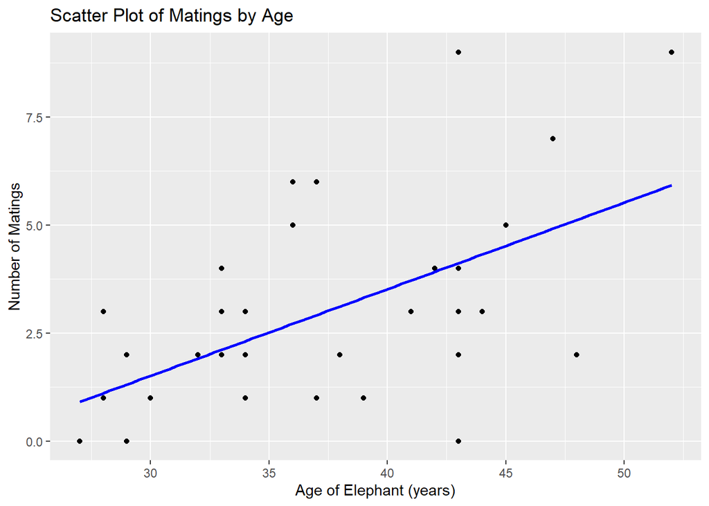

```r
ggplot(elephant, aes(x = AGE, y = MATINGS)) +
  geom_point() +
  geom_smooth(method = "lm", se = FALSE, color = "blue") +
  labs(title = "Scatter Plot of Matings by Age",
       x = "Age of Elephant (years)",
       y = "Number of Matings")
```

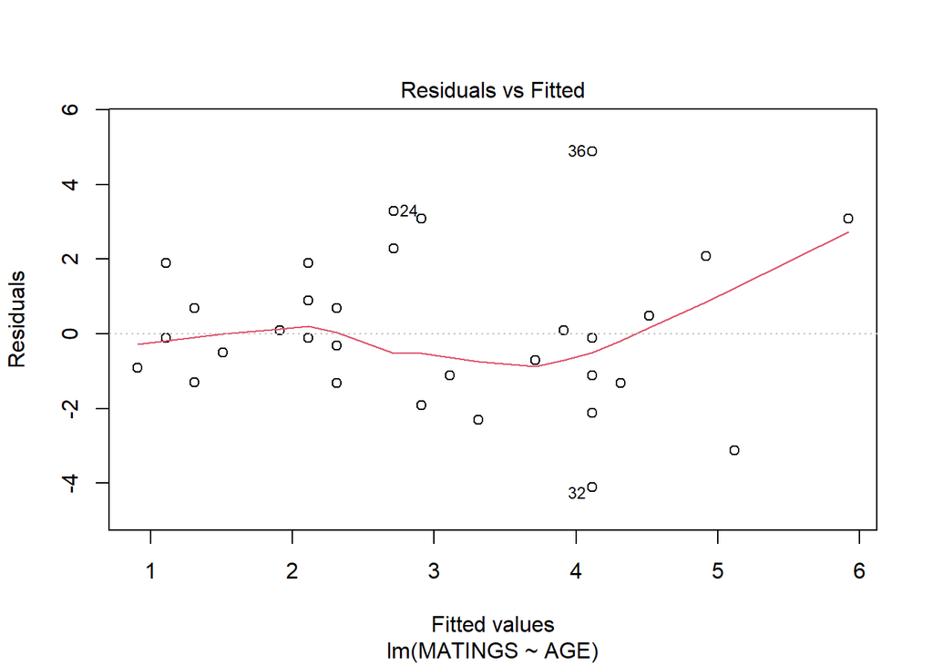

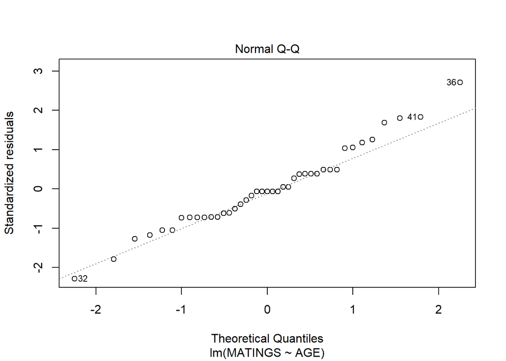

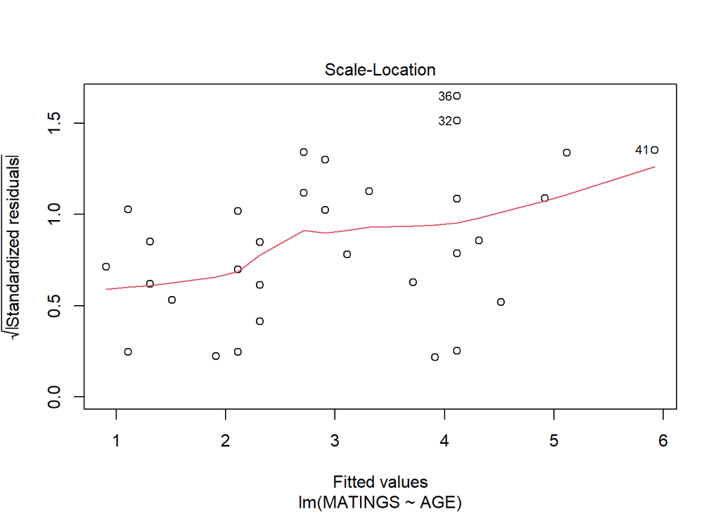

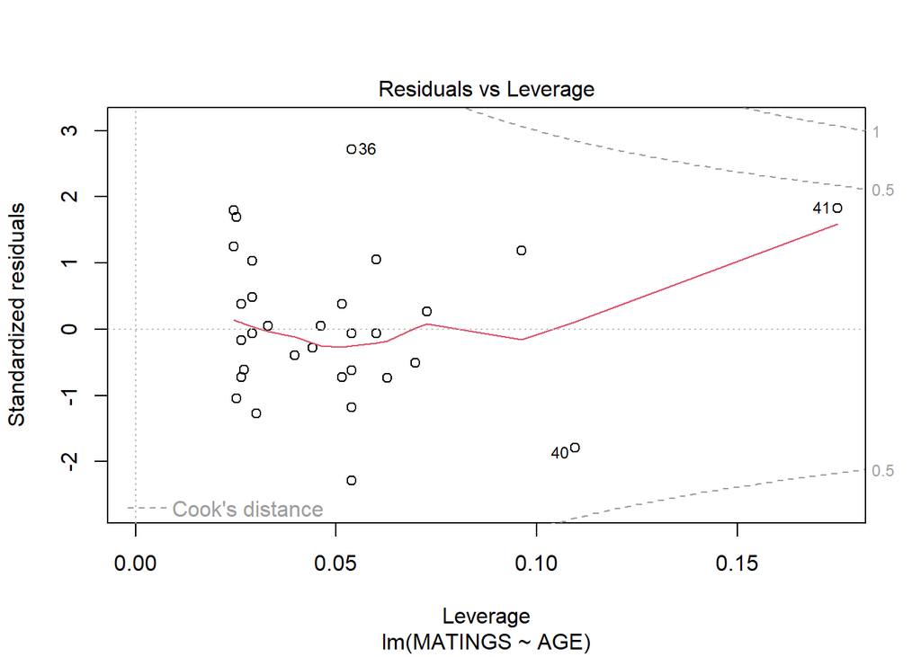

```r
elephant.model1 <- lm(MATINGS ~ AGE, data = elephant)

plot(elephant.model1)
```

Linearity from fitted vs residual plots seems to not pass and normallity doesn’t pass. No we can’t use LinReg. c. For each age, calculate the mean number of matings. Take the log of each mean and plot it by AGE. i. What assumption can be assessed with this plot? ii. Is there evidence of a quadratic trend on this plot?

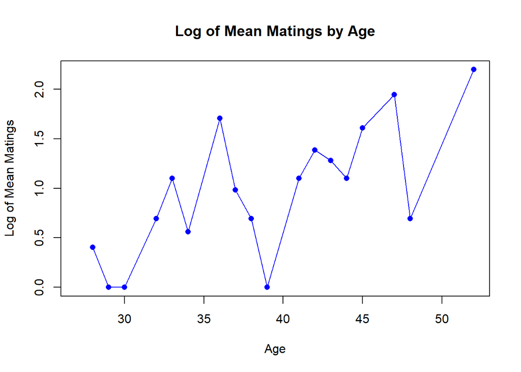

```r
mean_matings <- tapply(elephant$MATINGS, elephant$AGE, mean)

log_mean_matings <- log(mean_matings)
plot(names(log_mean_matings), log_mean_matings, type = "o", col = "blue", pch = 16, main = "Log of Mean Matings by Age", xlab = "Age", ylab = "Log of Mean Matings")
```

There is no evidence of a quadratic trend.

```
d. Fit a Poisson regression model with a linear term for AGE. Exponentiate and then interpret the coefficient for AGE.
```

```r
poisson_model <- glm(MATINGS ~ AGE, data = elephant, family = poisson)

summary(poisson_model)
```

```
##
## Call:
## glm(formula = MATINGS ~ AGE, family = poisson, data = elephant)
##
## Deviance Residuals:
##      Min        1Q    Median        3Q       Max
## -2.80798  -0.86137  -0.08629   0.60087   2.17777
##
## Coefficients:
##             Estimate Std. Error z value Pr(>|z|)
## (Intercept) -1.58201    0.54462  -2.905  0.00368 **
## AGE          0.06869    0.01375   4.997 5.81e-07 ***
## ---
## Signif. codes:  0 '***' 0.001 '**' 0.01 '*' 0.05 '.' 0.1 ' ' 1
##
## (Dispersion parameter for poisson family taken to be 1)
##
##     Null deviance: 75.372  on 40  degrees of freedom
## Residual deviance: 51.012  on 39  degrees of freedom
## AIC: 156.46
##
## Number of Fisher Scoring iterations: 5
```

```r
exp_coeff_age <- exp(coef(poisson_model)["AGE"])

cat("The exponentiated coefficient for AGE is:", exp_coeff_age, "\n")
```

```
## The exponentiated coefficient for AGE is: 1.071107
```

```r
cat("For each one-unit increase in AGE, the expected rate of matings increases by a factor of approximately", round(exp_coeff_age, 3), "\n")
```

```
## For each one-unit increase in AGE, the expected rate of matings increases by a factor of approximately 1.071
```

```
e. Construct a 95\% confidence interval for the slope and interpret in context (you may want to exponentiate endpoints).
```

```r
conf_interval_age <- confint(poisson_model, "AGE", level = 0.95)
exp_lower <- exp(conf_interval_age[1])
exp_upper <- exp(conf_interval_age[2])

cat("The 95% confidence interval for the exponentiated slope of AGE is [", round(exp_lower, 3), ", ", round(exp_upper, 3), "].\n")
```

```
## The 95% confidence interval for the exponentiated slope of AGE is [ 1.043 ,  1.1 ].
```

```r
cat("This means that we are 95% confident that a one-unit increase in AGE affects the rate of matings between", round(exp_lower, 3), "and", round(exp_upper, 3), ".\n")
```

```
## This means that we are 95% confident that a one-unit increase in AGE affects the rate of matings between 1.043 and 1.1 .
```

```
f. Are the number of matings significantly related to age? Test with
    i. a Wald test and
    ii. a drop in deviance test.
```

```r
library(aod)
wald_test_age <- wald.test(b = coef(poisson_model), Sigma = vcov(poisson_model), Terms = 2)

print(wald_test_age)
```

```
## Wald test:
## ----------
##
## Chi-squared test:
## X2 = 25.0, df = 1, P(> X2) = 5.8e-07
```

The wald test shows a very small p value this suggests that there is a significant relationship between the number of matings and age.

```r
null_model <- glm(MATINGS ~ 1, data = elephant, family = poisson)

drop_deviance_test <- anova(null_model, poisson_model, test = "Chisq")

print(drop_deviance_test)
```

```
## Analysis of Deviance Table
##
## Model 1: MATINGS ~ 1
## Model 2: MATINGS ~ AGE
##   Resid. Df Resid. Dev Df Deviance  Pr(>Chi)
## 1        40     75.372
## 2        39     51.012  1    24.36 7.991e-07 ***
## ---
## Signif. codes:  0 '***' 0.001 '**' 0.01 '*' 0.05 '.' 0.1 ' ' 1
```

The drop dev test shows a very small p value this suggests that there is a significant relationship between the number of matings and age.

```
g. Add a quadratic term in AGE to determine whether there is a maximum age for the number of matings for  elephants. Is a quadratic model preferred to a linear model? To investigate this question, use
    i. a Wald test and
    ii. a drop in deviance test.
```

```r
elephant <- elephant %>% mutate(AGE2 = AGE*AGE)

# Fit a Poisson regression model with linear and quadratic terms for AGE
quadratic_model <- glm(MATINGS ~ AGE + AGE2, data = elephant, family = poisson)
```

```r
wald_test_age2 <- wald.test(b = coef(quadratic_model), Sigma = vcov(quadratic_model), Terms = 3)

print(wald_test_age2)
```

```
## Wald test:
## ----------
##
## Chi-squared test:
## X2 = 0.18, df = 1, P(> X2) = 0.67
```

The p value is .67 showing no significant relationship between the number of matings^2 and age.

```r
linear_model <- glm(MATINGS ~ AGE, data = elephant, family = poisson)

drop_deviance_test_quad <- anova(linear_model, quadratic_model, test = "Chisq")

print(drop_deviance_test_quad)
```

```
## Analysis of Deviance Table
##
## Model 1: MATINGS ~ AGE
## Model 2: MATINGS ~ AGE + AGE2
##   Resid. Df Resid. Dev Df Deviance Pr(>Chi)
## 1        39     51.012
## 2        38     50.826  1  0.18544   0.6667
```

The p value is .67 showing no significant relationship between the number of matings^2 and age.

```
h. What can we say about the goodness-of-fit of the model with age as the sole predictor? Compare the residual deviance for the linear model to a $\chi^2$ distribution with the residual model degrees of freedom.
i. Fit the linear model using quasi-Poisson regression. (Why?)
    i. How do the estimated coefficients change?
    ii. How do the standard errors change?
    iii. What is the estimated dispersion parameter?
    iv. An estimated dispersion parameter greater than 1 suggests overdispersion. When adjusting for overdispersion, are you more or less likely to obtain a significant result when testing coefficients? Why?
```

```r
# GOODNESS OF FIT
df_residual <- df.residual(poisson_model)

residual_deviance <- deviance(poisson_model)

p_value_goodness_of_fit <- pchisq(residual_deviance, df_residual, lower.tail = FALSE)

cat("Residual Deviance:", residual_deviance, "\n")
```

```
## Residual Deviance: 51.01163
```

```r
cat("Degrees of Freedom:", df_residual, "\n")
```

```
## Degrees of Freedom: 39
```

```r
cat("P-value for Goodness-of-Fit Test:", p_value_goodness_of_fit, "\n")
```

```
## P-value for Goodness-of-Fit Test: 0.09426231
```

```r
quasi_poisson_model <- glm(MATINGS ~ AGE, data = elephant, family = quasipoisson)

summary(quasi_poisson_model)
```

```
##
## Call:
## glm(formula = MATINGS ~ AGE, family = quasipoisson, data = elephant)
##
## Deviance Residuals:
##      Min        1Q    Median        3Q       Max
## -2.80798  -0.86137  -0.08629   0.60087   2.17777
##
## Coefficients:
##             Estimate Std. Error t value Pr(>|t|)
## (Intercept) -1.58201    0.58590  -2.700   0.0102 *
## AGE          0.06869    0.01479   4.645 3.81e-05 ***
## ---
## Signif. codes:  0 '***' 0.001 '**' 0.01 '*' 0.05 '.' 0.1 ' ' 1
##
## (Dispersion parameter for quasipoisson family taken to be 1.157334)
##
##     Null deviance: 75.372  on 40  degrees of freedom
## Residual deviance: 51.012  on 39  degrees of freedom
## AIC: NA
##
## Number of Fisher Scoring iterations: 5
```

```r
summary(poisson_model)
```

```
##
## Call:
## glm(formula = MATINGS ~ AGE, family = poisson, data = elephant)
##
## Deviance Residuals:
##      Min        1Q    Median        3Q       Max
## -2.80798  -0.86137  -0.08629   0.60087   2.17777
##
## Coefficients:
##             Estimate Std. Error z value Pr(>|z|)
## (Intercept) -1.58201    0.54462  -2.905  0.00368 **
## AGE          0.06869    0.01375   4.997 5.81e-07 ***
## ---
## Signif. codes:  0 '***' 0.001 '**' 0.01 '*' 0.05 '.' 0.1 ' ' 1
##
## (Dispersion parameter for poisson family taken to be 1)
##
##     Null deviance: 75.372  on 40  degrees of freedom
## Residual deviance: 51.012  on 39  degrees of freedom
## AIC: 156.46
##
## Number of Fisher Scoring iterations: 5
```

The estimated coefs are consistent between models.  
The significants levels are similar.  
The standard errors are almost the same  
The estimated dispersion parameter for the quasi poisson model is 1.157334  
You are more likely to obtain wider confidence intervals and larger standard errors with overdispersion. This, in turn, makes it less likely to obtain a significant result when testing coefficients. Adjusting for overdispersion acknowledges that there is more variability in the data that isn’t accounted for in the model, making the results more conservative.

5. **Campus crime.** The data set `campuscrime09.csv` contains the number of burglaries reported at a collection of 47 U.S. public universities with over 10,000 students in the year 2009. In addition, covariates are included which may explain differences in crime rates, including total number of students, percentage of men, average SAT and ACT test scores, and tuition.
   1. Perform an exploratory data analysis. Support your analysis with plots and summary statistics.

```r
crime <- read.csv("data/campuscrime09.csv")
head(crime)
```

```
##   Idnum                       institution mentotal total pct.male sat.math
## 1    16       Central Michigan University    11517 27247 42.26887      540
## 2    51          East Carolina University    10830 27654 39.16251      520
## 3    60       Eastern Michigan University     9471 22893 41.37072      515
## 4    71           George Mason University    14467 32067 45.11492      565
## 5    73     Grand Valley State University     9752 24408 39.95411      580
## 6    92 Kent State University Kent Campus    10024 25127 39.89334      510
##   sat.read sat.tot state tuition act.comp burg09
## 1      525   532.5    MI   23590     22.0     27
## 2      495   507.5    NC   16386     21.0     10
## 3      510   512.5    MI    9278     20.5     42
## 4      550   557.5    VA   23376     25.0      4
## 5      550   565.0    MI    9630     24.0      1
## 6      515   512.5    OH   10006     21.5     15
```

```r
colnames(crime)
```

```
##  [1] "Idnum"       "institution" "mentotal"    "total"       "pct.male"
##  [6] "sat.math"    "sat.read"    "sat.tot"     "state"       "tuition"
## [11] "act.comp"    "burg09"
```

```
    i. Analyze whether number of burglaries could be reasonably modeled with a Poisson distribution.
```

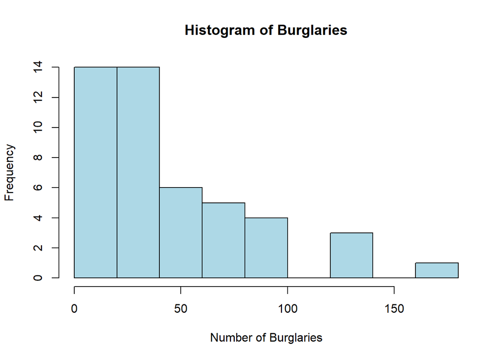

```r
hist(crime$burg09, main="Histogram of Burglaries", xlab="Number of Burglaries", col="lightblue", border="black")
```

This shows evidence that a poisson could be used due to the right skewwed histogram

```r
mean_burglaries <- mean(crime$burg09)
var_burglaries <- var(crime$burg09)

cat("Mean of Burglaries:", mean_burglaries, "\n")
```

```
## Mean of Burglaries: 44.23404
```

```r
cat("Variance of Burglaries:", var_burglaries, "\n")
```

```
## Variance of Burglaries: 1534.661
```

The mean is quite different from the varience showing we might not be able to use poisson

```
    ii. Analyze which covariates you expect to be the best predictors of burglaries.
```

```r
cor_matrix <- cor(crime[, c("burg09", "mentotal", "total", "pct.male", "sat.math", "sat.read", "sat.tot", "tuition", "act.comp")])

print(cor_matrix)
```

```
##               burg09  mentotal     total    pct.male   sat.math   sat.read
## burg09    1.00000000 0.2789389 0.2950930  0.08230229 0.25211282 0.22770322
## mentotal  0.27893894 1.0000000 0.9642051  0.55903758 0.53431108 0.41351456
## total     0.29509297 0.9642051 1.0000000  0.32681914 0.54416990 0.44978956
## pct.male  0.08230229 0.5590376 0.3268191  1.00000000 0.21628187 0.07305566
## sat.math  0.25211282 0.5343111 0.5441699  0.21628187 1.00000000 0.85603403
## sat.read  0.22770322 0.4135146 0.4497896  0.07305566 0.85603403 1.00000000
## sat.tot   0.25050751 0.4996930 0.5218601  0.15963367 0.97232350 0.95311437
## tuition  -0.17929390 0.2039375 0.2551053 -0.13252489 0.06289644 0.05369193
## act.comp  0.26377721 0.4930116 0.4930079  0.22894725 0.90405514 0.90080487
##             sat.tot     tuition   act.comp
## burg09   0.25050751 -0.17929390 0.26377721
## mentotal 0.49969297  0.20393752 0.49301161
## total    0.52186010  0.25510531 0.49300790
## pct.male 0.15963367 -0.13252489 0.22894725
## sat.math 0.97232350  0.06289644 0.90405514
## sat.read 0.95311437  0.05369193 0.90080487
## sat.tot  1.00000000  0.06108809 0.93639197
## tuition  0.06108809  1.00000000 0.09230963
## act.comp 0.93639197  0.09230963 1.00000000
```

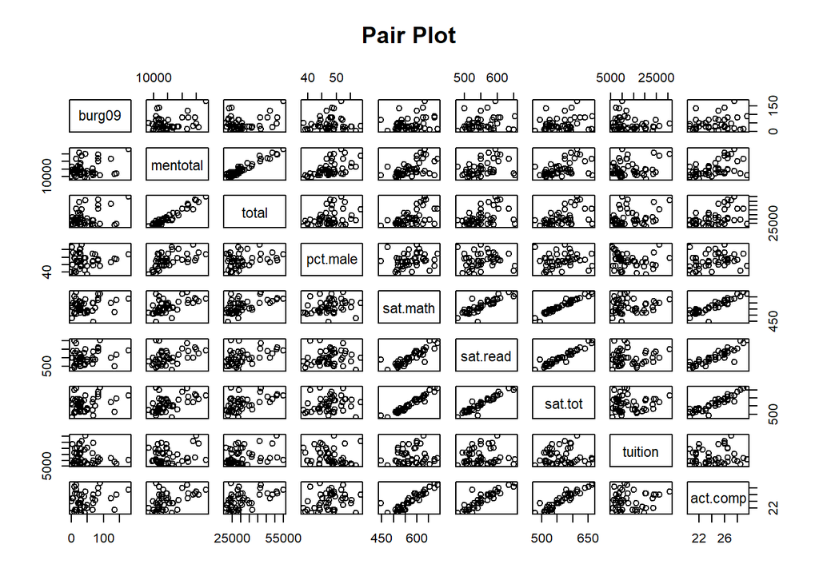

```r
pairs(crime[, c("burg09", "mentotal", "total", "pct.male", "sat.math", "sat.read", "sat.tot", "tuition", "act.comp")], main="Pair Plot")
```

```r
crime.model1 <- lm(burg09 ~ total +sat.math+sat.read+sat.tot+tuition+act.comp , data=crime)

summary(crime.model1)
```

```
##
## Call:
## lm(formula = burg09 ~ total + sat.math + sat.read + sat.tot +
##     tuition + act.comp, data = crime)
##
## Residuals:
##    Min     1Q Median     3Q    Max
## -53.07 -25.94 -10.09  15.19  98.62
##
## Coefficients: (1 not defined because of singularities)
##               Estimate Std. Error t value Pr(>|t|)
## (Intercept) -5.8306848 82.8316267  -0.070   0.9442
## total        0.0013767  0.0007828   1.759   0.0861 .
## sat.math    -0.0757429  0.2593019  -0.292   0.7717
## sat.read    -0.0774163  0.3173829  -0.244   0.8085
## sat.tot             NA         NA      NA       NA
## tuition     -0.0016978  0.0009131  -1.859   0.0702 .
## act.comp     4.7747556  6.3811978   0.748   0.4586
## ---
## Signif. codes:  0 '***' 0.001 '**' 0.01 '*' 0.05 '.' 0.1 ' ' 1
##
## Residual standard error: 37.67 on 41 degrees of freedom
## Multiple R-squared:  0.1759, Adjusted R-squared:  0.0754
## F-statistic:  1.75 on 5 and 41 DF,  p-value: 0.1448
```

total students, all sat and act predictors, and tuition. We would only want to use total for sat or act. b. Consider a model with 4 predictors: `act.comp + tuition + pct.male + total`. Try fitting a linear regression with `burg09` as the response. Are there any concerns with this linear regression model?

```r
model <- lm(burg09 ~ act.comp + tuition + pct.male + total, data=crime)

summary(model)
```

```
##
## Call:
## lm(formula = burg09 ~ act.comp + tuition + pct.male + total,
##     data = crime)
##
## Residuals:
##    Min     1Q Median     3Q    Max
## -58.35 -24.71  -4.64  16.03 101.26
##
## Coefficients:
##               Estimate Std. Error t value Pr(>|t|)
## (Intercept)  3.7889197 75.4066999   0.050   0.9602
## act.comp     2.3845399  2.5249907   0.944   0.3504
## tuition     -0.0017851  0.0009177  -1.945   0.0585 .
## pct.male    -0.8219242  1.2885673  -0.638   0.5270
## total        0.0014540  0.0007756   1.875   0.0678 .
## ---
## Signif. codes:  0 '***' 0.001 '**' 0.01 '*' 0.05 '.' 0.1 ' ' 1
##
## Residual standard error: 37.12 on 42 degrees of freedom
## Multiple R-squared:  0.1801, Adjusted R-squared:  0.102
## F-statistic: 2.307 on 4 and 42 DF,  p-value: 0.07387
```

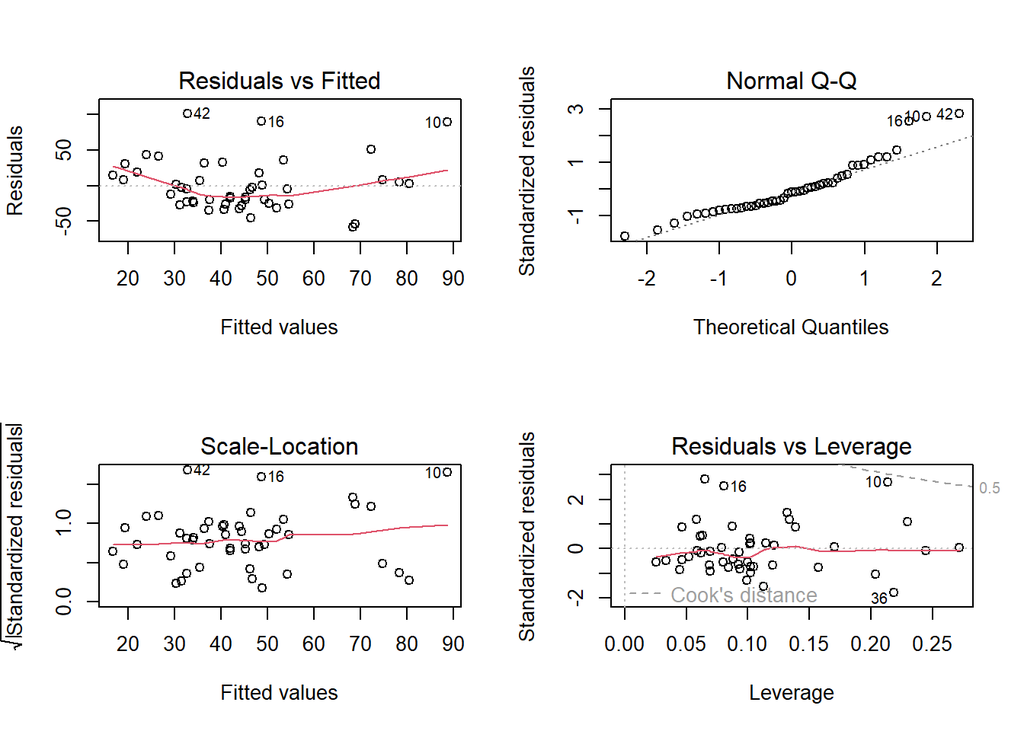

```r
par(mfrow=c(2,2))
plot(model)
```

We have some normallity and linearity issues as seen in normal qq and res vs fit. The model is also not significant.

```
c. Run a Poisson regression model with the 4 predictors from (b).  Interpret the coefficients for `tuition` and `pct.male`.
```

```r
poisson_model <- glm(burg09 ~ act.comp + tuition + pct.male + total, data=crime, family=poisson)

summary(poisson_model)
```

```
##
## Call:
## glm(formula = burg09 ~ act.comp + tuition + pct.male + total,
##     family = poisson, data = crime)
##
## Deviance Residuals:
##     Min       1Q   Median       3Q      Max
## -8.9601  -4.3267  -0.7979   2.0759  12.9673
##
## Coefficients:
##               Estimate Std. Error z value Pr(>|z|)
## (Intercept)  2.741e+00  3.238e-01   8.465  < 2e-16 ***
## act.comp     5.352e-02  1.008e-02   5.308 1.11e-07 ***
## tuition     -3.896e-05  3.937e-06  -9.894  < 2e-16 ***
## pct.male    -1.313e-02  5.355e-03  -2.452   0.0142 *
## total        2.666e-05  2.745e-06   9.709  < 2e-16 ***
## ---
## Signif. codes:  0 '***' 0.001 '**' 0.01 '*' 0.05 '.' 0.1 ' ' 1
##
## (Dispersion parameter for poisson family taken to be 1)
##
##     Null deviance: 1400.0  on 46  degrees of freedom
## Residual deviance: 1133.6  on 42  degrees of freedom
## AIC: 1389
##
## Number of Fisher Scoring iterations: 5
```

```r
exp_coef <- exp(coef(poisson_model))

print(exp_coef)
```

```
## (Intercept)    act.comp     tuition    pct.male       total
##  15.4979106   1.0549809   0.9999610   0.9869548   1.0000267
```

For a one-unit increase in the percentage of males (pct.male), the expected log-count of burglaries decreases by approximately 0.01313, holding other predictors constant.

For a one-unit increase in tuition, the expected log-count of burglaries decreases by approximately 0.00003896, holding other predictors constant.

```
d. Replace `tuition` with tuition in thousands in your model from (c) – i.e., `tuition.thous`=`tuition`/1000.  How does your new model compare to your model in (c)?  Interpret the coefficient for `tuition.thous`.
```

```r
crime$tuition.thous <- crime$tuition / 1000

poisson_model_new <- glm(burg09 ~ act.comp + tuition.thous + pct.male + total, data=crime, family=poisson)

summary(poisson_model_new)
```

```
##
## Call:
## glm(formula = burg09 ~ act.comp + tuition.thous + pct.male +
##     total, family = poisson, data = crime)
##
## Deviance Residuals:
##     Min       1Q   Median       3Q      Max
## -8.9601  -4.3267  -0.7979   2.0759  12.9673
##
## Coefficients:
##                 Estimate Std. Error z value Pr(>|z|)
## (Intercept)    2.741e+00  3.238e-01   8.465  < 2e-16 ***
## act.comp       5.352e-02  1.008e-02   5.308 1.11e-07 ***
## tuition.thous -3.896e-02  3.937e-03  -9.894  < 2e-16 ***
## pct.male      -1.313e-02  5.355e-03  -2.452   0.0142 *
## total          2.666e-05  2.745e-06   9.709  < 2e-16 ***
## ---
## Signif. codes:  0 '***' 0.001 '**' 0.01 '*' 0.05 '.' 0.1 ' ' 1
##
## (Dispersion parameter for poisson family taken to be 1)
##
##     Null deviance: 1400.0  on 46  degrees of freedom
## Residual deviance: 1133.6  on 42  degrees of freedom
## AIC: 1389
##
## Number of Fisher Scoring iterations: 5
```

```r
coefficients <- coef(poisson_model_new)

exp_coefficients <- exp(coefficients)

print(exp_coefficients)
```

```
##   (Intercept)      act.comp tuition.thous      pct.male         total
##    15.4979106     1.0549809     0.9617923     0.9869548     1.0000267
```

For a one-unit increase in tuition, the expected number of burglaries should be multiplied by 0.9617, holding other predictors constant.

```
e. We will consider the possibility of including the total number of students at a university as an offset.
    i. Explain why we might consider `total` as an offset.
```

Total represents the exposure or opportunity for burglaries to occur. The idea is that the number of burglaries may be influenced by the size of the student population. ii. Refit your model from (d) with total (actually, log(total)) as an offset rather than as a predictor. Does this new model appear to fit better or worse than the model from (d)?

```r
crime$log_total <- log(crime$total)

poisson_model_offset <- glm(burg09 ~ act.comp + tuition.thous + pct.male + offset(log_total), data=crime, family=poisson)

summary(poisson_model_offset)
```

```
##
## Call:
## glm(formula = burg09 ~ act.comp + tuition.thous + pct.male +
##     offset(log_total), family = poisson, data = crime)
##
## Deviance Residuals:
##     Min       1Q   Median       3Q      Max
## -9.0845  -4.3325  -0.6885   2.1165  13.3356
##
## Coefficients:
##                Estimate Std. Error z value Pr(>|z|)
## (Intercept)   -6.630845   0.303476 -21.850  < 2e-16 ***
## act.comp       0.051452   0.008873   5.799 6.67e-09 ***
## tuition.thous -0.039705   0.003821 -10.391  < 2e-16 ***
## pct.male      -0.014285   0.005112  -2.794   0.0052 **
## ---
## Signif. codes:  0 '***' 0.001 '**' 0.01 '*' 0.05 '.' 0.1 ' ' 1
##
## (Dispersion parameter for poisson family taken to be 1)
##
##     Null deviance: 1328.3  on 46  degrees of freedom
## Residual deviance: 1186.2  on 43  degrees of freedom
## AIC: 1439.7
##
## Number of Fisher Scoring iterations: 5
```

The deviance residuals in the new model are slightly higher, indicating a slightly worse fit compared to the previous mode  
The AIC has increased in the new model, suggesting a decrease in model fit

[output not shown]

```r
poisson_model_log_total <- glm(burg09 ~ act.comp + tuition.thous + pct.male + log(total), data=crime, family=poisson)

summary(poisson_model_log_total)
```

```
##
## Call:
## glm(formula = burg09 ~ act.comp + tuition.thous + pct.male +
##     log(total), family = poisson, data = crime)
##
## Deviance Residuals:
##    Min      1Q  Median      3Q     Max
## -9.306  -4.219  -1.175   1.881  12.957
##
## Coefficients:
##                Estimate Std. Error z value Pr(>|z|)
## (Intercept)   -4.107092   0.886730  -4.632 3.63e-06 ***
## act.comp       0.065634   0.009921   6.616 3.70e-11 ***
## tuition.thous -0.036648   0.003940  -9.300  < 2e-16 ***
## pct.male      -0.009317   0.005324  -1.750   0.0801 .
## log(total)     0.696416   0.099891   6.972 3.13e-12 ***
## ---
## Signif. codes:  0 '***' 0.001 '**' 0.01 '*' 0.05 '.' 0.1 ' ' 1
##
## (Dispersion parameter for poisson family taken to be 1)
##
##     Null deviance: 1400  on 46  degrees of freedom
## Residual deviance: 1177  on 42  degrees of freedom
## AIC: 1432.4
##
## Number of Fisher Scoring iterations: 5
```

```r
coef_log_total <- confint(poisson_model_log_total)["log(total)", ]
print(coef_log_total)
```

```
##     2.5 %    97.5 %
## 0.5003239 0.8919343
```

No. Since this interval does not include the value 1, it suggests that treating total as an offset may not be appropriate in this case.

```
f. Run the following model, then interpret the coefficients for `tuition.thous` and the interaction between `tuition.thous` and `act.comp`.
```

```r
crime <- mutate(crime, total.thous = total/1000)
    fit3 <- glm(burg09 ~ act.comp + tuition.thous +
            total.thous + act.comp:tuition.thous +
            act.comp:total.thous, family = poisson,
            data = crime)
summary(fit3)
```

```
##
## Call:
## glm(formula = burg09 ~ act.comp + tuition.thous + total.thous +
##     act.comp:tuition.thous + act.comp:total.thous, family = poisson,
##     data = crime)
##
## Deviance Residuals:
##    Min      1Q  Median      3Q     Max
## -9.985  -3.473  -0.849   1.594  11.738
##
## Coefficients:
##                         Estimate Std. Error z value Pr(>|z|)
## (Intercept)             7.107921   1.240955   5.728 1.02e-08 ***
## act.comp               -0.135003   0.048251  -2.798 0.005143 **
## tuition.thous           0.145144   0.043694   3.322 0.000894 ***
## total.thous            -0.218165   0.036772  -5.933 2.98e-09 ***
## act.comp:tuition.thous -0.007247   0.001751  -4.138 3.50e-05 ***
## act.comp:total.thous    0.009273   0.001390   6.671 2.54e-11 ***
## ---
## Signif. codes:  0 '***' 0.001 '**' 0.01 '*' 0.05 '.' 0.1 ' ' 1
##
## (Dispersion parameter for poisson family taken to be 1)
##
##     Null deviance: 1400.0  on 46  degrees of freedom
## Residual deviance: 1073.7  on 41  degrees of freedom
## AIC: 1331.2
##
## Number of Fisher Scoring iterations: 5
```

```r
coefficients <- coef(fit3)

exp_coefficients <- exp(coefficients)

print(exp_coefficients)
```

```
##            (Intercept)               act.comp          tuition.thous
##           1221.6046391              0.8737132              1.1562058
##            total.thous act.comp:tuition.thous   act.comp:total.thous
##              0.8039931              0.9927793              1.0093165
```

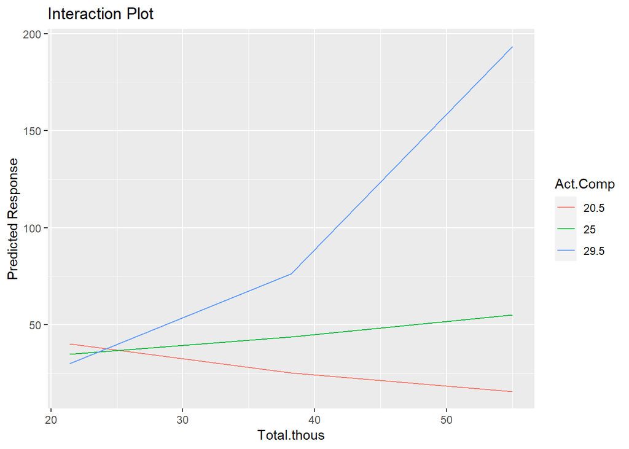

```r
df_interaction <- expand.grid(
  total.thous = seq(min(crime$total.thous), max(crime$total.thous), length.out = 3),
  act.comp = seq(min(crime$act.comp), max(crime$act.comp), length.out = 3),
  tuition.thous = mean(crime$tuition.thous)
)

df_interaction$predicted <- predict(fit3, newdata = df_interaction, type = "response")


ggplot(df_interaction, aes(x = total.thous, y = predicted, color = factor(act.comp))) +
  geom_line() +
  labs(title = "Interaction Plot",
       x = "Total.thous",
       y = "Predicted Response",
       color = "Act.Comp")
```

For a one-unit increase in tuition in thousands, while holding other variables constant, the number of burglaries is expected to multiply by 1.1562058 .

For the interaction between act comp and total.thous please see above graph

6. **U.S. National Medical Expenditure Survey.** The data set `NMES1988` in the `AER` package contains a sample of individuals over 65 who are covered by Medicare in order to assess the demand for health care through physician office visits, outpatient visits, ER visits, hospital stays, etc. The data can be accessed by installing and loading the `AER` package and then running `data(NMES1988)`. More background information and references about the `NMES1988` data can be found in help pages for the `AER` package.
   1. Show through graphical means that there are more respondents with 0 `visits` than might be expected under a Poisson model.

```r
library(AER)
data(NMES1988)
nmes <- NMES1988
str(NMES1988)
```

```
## 'data.frame':    4406 obs. of  19 variables:
##  $ visits   : int  5 1 13 16 3 17 9 3 1 0 ...
##  $ nvisits  : int  0 0 0 0 0 0 0 0 0 0 ...
##  $ ovisits  : int  0 2 0 5 0 0 0 0 0 0 ...
##  $ novisits : int  0 0 0 0 0 0 0 0 0 0 ...
##  $ emergency: int  0 2 3 1 0 0 0 0 0 0 ...
##  $ hospital : int  1 0 3 1 0 0 0 0 0 0 ...
##  $ health   : Factor w/ 3 levels "poor","average",..: 2 2 1 1 2 1 2 2 2 2 ...
##   ..- attr(*, "contrasts")= num [1:3, 1:2] 1 0 0 0 0 1
##   .. ..- attr(*, "dimnames")=List of 2
##   .. .. ..$ : chr [1:3] "poor" "average" "excellent"
##   .. .. ..$ : chr [1:2] "poor" "excellent"
##  $ chronic  : int  2 2 4 2 2 5 0 0 0 0 ...
##  $ adl      : Factor w/ 2 levels "normal","limited": 1 1 2 2 2 2 1 1 1 1 ...
##  $ region   : Factor w/ 4 levels "northeast","midwest",..: 4 4 4 4 4 4 2 2 2 2 ...
##   ..- attr(*, "contrasts")= num [1:4, 1:3] 1 0 0 0 0 1 0 0 0 0 ...
##   .. ..- attr(*, "dimnames")=List of 2
##   .. .. ..$ : chr [1:4] "northeast" "midwest" "west" "other"
##   .. .. ..$ : chr [1:3] "northeast" "midwest" "west"
##  $ age      : num  6.9 7.4 6.6 7.6 7.9 6.6 7.5 8.7 7.3 7.8 ...
##  $ afam     : Factor w/ 2 levels "no","yes": 2 1 2 1 1 1 1 1 1 1 ...
##  $ gender   : Factor w/ 2 levels "female","male": 2 1 1 2 1 1 1 1 1 1 ...
##  $ married  : Factor w/ 2 levels "no","yes": 2 2 1 2 2 1 1 1 1 1 ...
##  $ school   : int  6 10 10 3 6 7 8 8 8 8 ...
##  $ income   : num  2.881 2.748 0.653 0.659 0.659 ...
##  $ employed : Factor w/ 2 levels "no","yes": 2 1 1 1 1 1 1 1 1 1 ...
##  $ insurance: Factor w/ 2 levels "no","yes": 2 2 1 2 2 1 2 2 2 2 ...
##  $ medicaid : Factor w/ 2 levels "no","yes": 1 1 2 1 1 2 1 1 1 1 ...
```

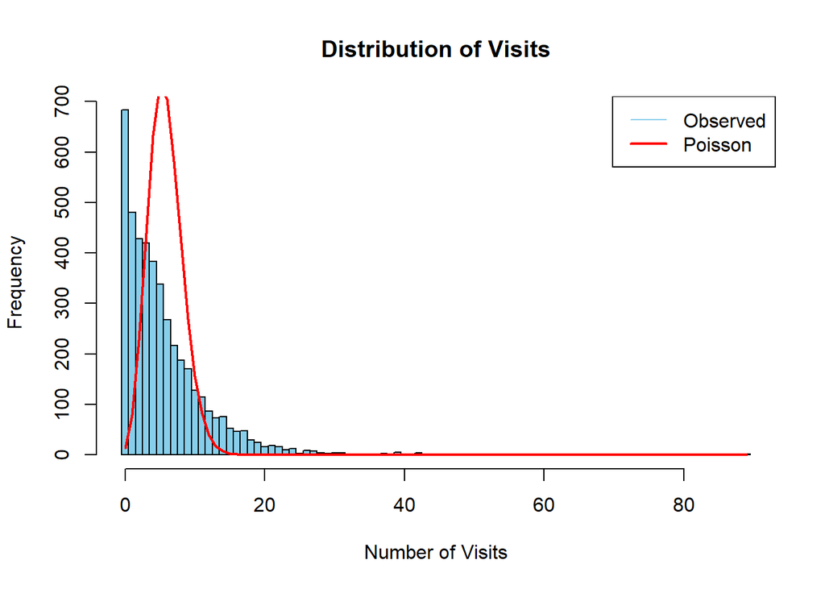

```r
visits_data <- nmes$visits

hist(visits_data, breaks = seq(-0.5, max(visits_data) + 0.5, 1),
     col = "skyblue", main = "Distribution of Visits",
     xlab = "Number of Visits", ylab = "Frequency")

lambda <- mean(visits_data)
x <- seq(0, max(visits_data), 1)
poisson_prob <- dpois(x, lambda)
lines(x, poisson_prob * length(visits_data), col = "red", lwd = 2)
legend("topright", legend = c("Observed", "Poisson"), col = c("skyblue", "red"), lwd = c(1, 2))
```

b. Fit a ZIP model for the number of physician office `visits` using `chronic`, `health`, and `insurance` as predictors for the Poisson count, and `chronic` and `insurance` as the predictors for the binary part of the model. Then, provide interpretations in context for the following model parameters:

```
- `chronic` in the Poisson part of the model
- poor `health` in the Poisson part of the model
- the Intercept in the logistic part of the model
- `insurance` in the logistic part of the model
```

```r
install.packages("pscl")
library(pscl)

zip_model <- zeroinfl(visits ~ chronic + health + insurance | chronic + insurance, data = nmes, dist = "poisson")

summary(zip_model)
```

```
##
## Call:
## zeroinfl(formula = visits ~ chronic + health + insurance | chronic +
##     insurance, data = nmes, dist = "poisson")
##
## Pearson residuals:
##     Min      1Q  Median      3Q     Max
## -3.9221 -1.2195 -0.4316  0.5598 24.1031
##
## Count model coefficients (poisson with log link):
##                 Estimate Std. Error z value Pr(>|z|)
## (Intercept)      1.55878    0.01762  88.448   <2e-16 ***
## chronic          0.11868    0.00462  25.691   <2e-16 ***
## healthpoor       0.29470    0.01729  17.043   <2e-16 ***
## healthexcellent -0.30482    0.03115  -9.786   <2e-16 ***
## insuranceyes     0.14467    0.01631   8.870   <2e-16 ***
##
## Zero-inflation model coefficients (binomial with logit link):
##              Estimate Std. Error z value Pr(>|z|)
## (Intercept)  -0.37426    0.09213  -4.062 4.86e-05 ***
## chronic      -0.56112    0.04334 -12.948  < 2e-16 ***
## insuranceyes -0.88314    0.09464  -9.332  < 2e-16 ***
## ---
## Signif. codes:  0 '***' 0.001 '**' 0.01 '*' 0.05 '.' 0.1 ' ' 1
##
## Number of iterations in BFGS optimization: 11
## Log-likelihood: -1.651e+04 on 8 Df
```

```r
coefficients <- coef(zip_model)

exp_coefficients <- exp(coefficients)

print(exp_coefficients)
```

```
##     count_(Intercept)         count_chronic      count_healthpoor
##             4.7530279             1.1260078             1.3427272
## count_healthexcellent    count_insuranceyes      zero_(Intercept)
##             0.7372574             1.1556581             0.6878008
##          zero_chronic     zero_insuranceyes
##             0.5705708             0.4134809
```

holding all other variables constant, individuals with a chronic condition have an expected count of doctor visits about 1.13 times higher compared to those without a chronic condition.

individuals reporting poor health compared to those reporting good health have an expected count of doctor visits about 1.34 times higher compared to those with a different health status, controlling for other variables.  
individuals reporting excellent health compared to those reporting good health have an expected count of doctor visits about 0.74 times the count of individuals with a different health status, holding other factors constant  
individuals with health insurance have an expected count of doctor visits about 1.16 times higher than those without insurance, controlling for other predictors.

###Zero-Inflation-logit

individuals with a chronic condition have odds of not going to the doctor 0.57 times lower compared to those without a chronic condition, holding other variables constant.  
individuals with health insurance have odds of not going to the doctor 0.41 times lower compared to those without insurance, controlling for other predictors.

```
c. Is there significant evidence that the ZIP model is an improvement over a simple Poisson regression model?
```

```r
poisson_model <- glm(visits ~ chronic + health + insurance, data = nmes, family = "poisson")

lr_test <- lrtest(poisson_model, zip_model)
print(lr_test)
```

```
## Likelihood ratio test
##
## Model 1: visits ~ chronic + health + insurance
## Model 2: visits ~ chronic + health + insurance | chronic + insurance
##   #Df LogLik Df  Chisq Pr(>Chisq)
## 1   5 -18426
## 2   8 -16515  3 3821.9  < 2.2e-16 ***
## ---
## Signif. codes:  0 '***' 0.001 '**' 0.01 '*' 0.05 '.' 0.1 ' ' 1
```

Based on the likelihood ratio test results, there is significant evidence that the zip model is an improvement over the Poisson model. The chisq is 3821.9 with 3 degrees of freedom, and the p-value is small.

### Open-Ended Exercises

1. **Airbnb in NYC.** @Awad2017 scraped 40628 Airbnb listings from New York City in March 2017 and put together the data set `NYCairbnb.csv`. Key variables include:
   - `id` = unique ID number for each unit
   - `last_scraped` = date when information scraped
   - `host_since` = date when host first listed the unit on Airbnb
   - `days` = `last_scraped` - `host_since` = number of days the unit has been listed
   - `room_type` = Entire home/apt., Private room, or Shared room
   - `bathrooms` = number of bathrooms
   - `bedrooms` = number of bedrooms
   - `price` = price per night (dollars)
   - `number_of_reviews` = number of reviews for the unit on Airbnb
   - `review_scores_cleanliness` = cleanliness score from reviews (1-10)
   - `review_scores_location` = location score from reviews (1-10)
   - `review_scores_value` = value score from reviews (1-10)
   - `instant_bookable` = “t” if instantly bookable, “f” if not

   Perform an EDA, build a model, and interpret model coefficients to describe variation in the number of reviews (a proxy for the number of rentals, which is not available) as a function of the variables provided. Don’t forget to consider an offset, if needed.

```r
airbnb <- read.csv("data/NYCairbnb.csv")



airbnb$bin_days <- cut(airbnb$days, breaks = quantile(airbnb$days, probs = seq(0, 1, 0.1), na.rm = TRUE), labels = paste0("Bin ", 1:10))



airbnb$instant_bookable <- ifelse(airbnb$instant_bookable == 'f', 0, 1)

head(airbnb)
```

```
##     id days last_scraped host_since       room_type bathrooms bedrooms price
## 1 2515 3130     4/2/2017   9/6/2008    Private room         1        1    59
## 2 2595 3127     4/2/2017   9/9/2008 Entire home/apt         1        0   230
## 3 3647 3050     4/2/2017 11/25/2008    Private room         1        1   150
## 4 3831 3038     4/2/2017  12/7/2008 Entire home/apt         1        1    89
## 5 4611 3012     4/2/2017   1/2/2009    Private room        NA        1    39
## 6 5099 2981     4/2/2017   2/2/2009 Entire home/apt         1        1   212
##   number_of_reviews review_scores_cleanliness review_scores_location
## 1               150                         9                      9
## 2                20                         9                     10
## 3                 0                        NA                     NA
## 4               116                         9                      9
## 5                93                         9                      8
## 6                60                         9                      9
##   review_scores_value instant_bookable bin_days
## 1                   9                0   Bin 10
## 2                   9                0   Bin 10
## 3                  NA                0   Bin 10
## 4                   9                0   Bin 10
## 5                   9                1   Bin 10
## 6                   9                0   Bin 10
```

```r
summary(airbnb)
```

```
##        id                days       last_scraped        host_since
##  Min.   :    2515   Min.   :    1   Length:40628       Length:40628
##  1st Qu.: 4889868   1st Qu.:  542   Class :character   Class :character
##  Median : 9862878   Median :  996   Mode  :character   Mode  :character
##  Mean   : 9698889   Mean   : 1102
##  3rd Qu.:14667894   3rd Qu.: 1535
##  Max.   :18009669   Max.   :42828
##
##   room_type           bathrooms        bedrooms          price
##  Length:40628       Min.   :0.000   Min.   : 0.000   Min.   :   10.0
##  Class :character   1st Qu.:1.000   1st Qu.: 1.000   1st Qu.:   70.0
##  Mode  :character   Median :1.000   Median : 1.000   Median :  100.0
##                     Mean   :1.125   Mean   : 1.147   Mean   :  144.8
##                     3rd Qu.:1.000   3rd Qu.: 1.000   3rd Qu.:  170.0
##                     Max.   :8.000   Max.   :10.000   Max.   :10000.0
##                     NA's   :160     NA's   :76
##  number_of_reviews review_scores_cleanliness review_scores_location
##  Min.   :  0.0     Min.   : 2.000            Min.   : 2.000
##  1st Qu.:  1.0     1st Qu.: 9.000            1st Qu.: 9.000
##  Median :  4.0     Median :10.000            Median :10.000
##  Mean   : 15.9     Mean   : 9.198            Mean   : 9.414
##  3rd Qu.: 17.0     3rd Qu.:10.000            3rd Qu.:10.000
##  Max.   :421.0     Max.   :10.000            Max.   :10.000
##                    NA's   :10195             NA's   :10254
##  review_scores_value instant_bookable    bin_days
##  Min.   : 2.000      Min.   :0.0000   Bin 2  : 4096
##  1st Qu.: 9.000      1st Qu.:0.0000   Bin 5  : 4071
##  Median :10.000      Median :0.0000   Bin 8  : 4068
##  Mean   : 9.332      Mean   :0.1937   Bin 1  : 4065
##  3rd Qu.:10.000      3rd Qu.:0.0000   Bin 7  : 4064
##  Max.   :10.000      Max.   :1.0000   (Other):20257
##  NA's   :10256                        NA's   :    7
```

```r
str(airbnb)
```

```
## 'data.frame':    40628 obs. of  14 variables:
##  $ id                       : int  2515 2595 3647 3831 4611 5099 5107 5121 5172 5178 ...
##  $ days                     : int  3130 3127 3050 3038 3012 2981 2981 2980 2980 2952 ...
##  $ last_scraped             : chr  "4/2/2017" "4/2/2017" "4/2/2017" "4/2/2017" ...
##  $ host_since               : chr  "9/6/2008" "9/9/2008" "11/25/2008" "12/7/2008" ...
##  $ room_type                : chr  "Private room" "Entire home/apt" "Private room" "Entire home/apt" ...
##  $ bathrooms                : num  1 1 1 1 NA 1 1 NA 1 1 ...
##  $ bedrooms                 : int  1 0 1 1 1 1 2 1 1 1 ...
##  $ price                    : int  59 230 150 89 39 212 250 60 129 79 ...
##  $ number_of_reviews        : int  150 20 0 116 93 60 60 50 53 329 ...
##  $ review_scores_cleanliness: int  9 9 NA 9 9 9 10 8 9 7 ...
##  $ review_scores_location   : int  9 10 NA 9 8 9 9 9 10 10 ...
##  $ review_scores_value      : int  9 9 NA 9 9 9 10 9 9 9 ...
##  $ instant_bookable         : num  0 0 0 0 1 0 0 0 0 0 ...
##  $ bin_days                 : Factor w/ 10 levels "Bin 1","Bin 2",..: 10 10 10 10 10 10 10 10 10 10 ...
```

```r
sum(is.na(airbnb))
```

```
## [1] 30983
```

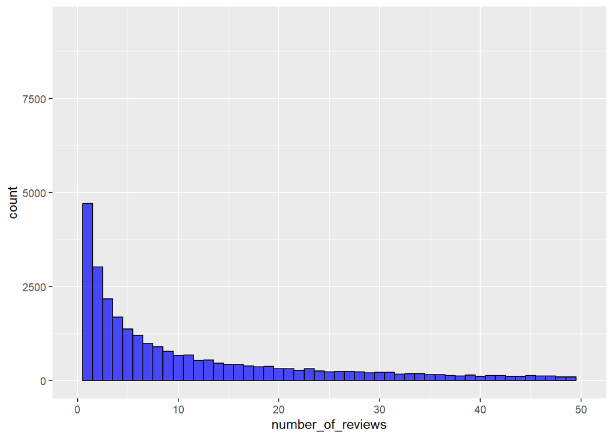

```r
ggplot(airbnb, aes(x = number_of_reviews)) +
  geom_histogram(binwidth = 1, fill = "blue", color = "black", alpha = 0.7) +
  xlim(0, 50)
```

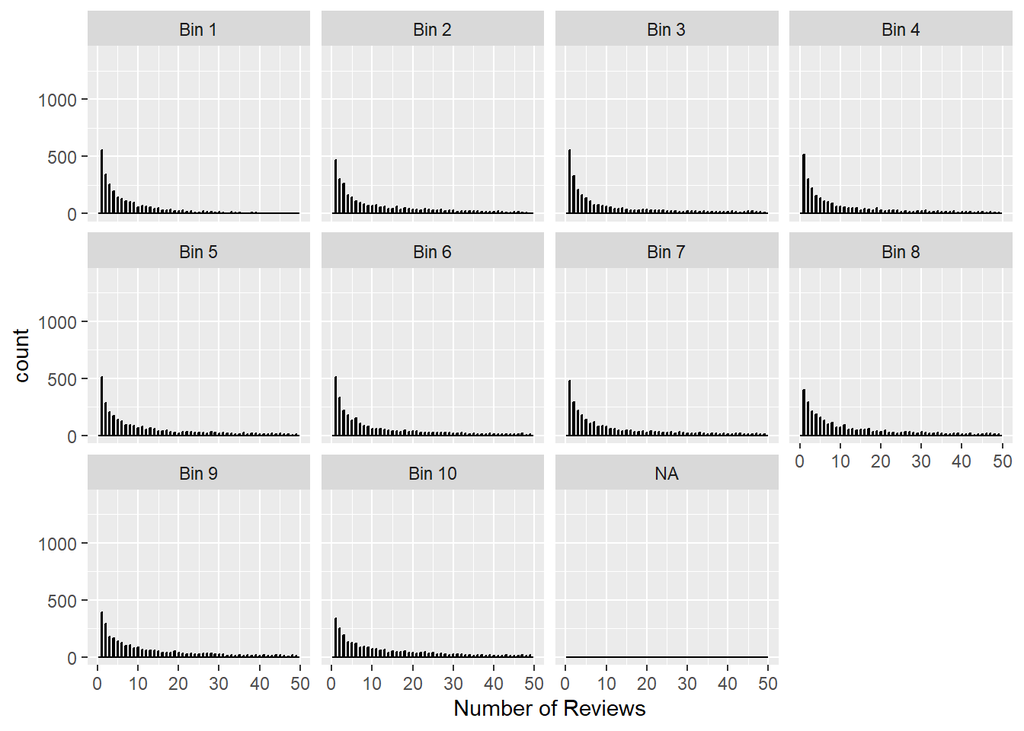

```r
ggplot(data = airbnb, aes(x = number_of_reviews)) +
  geom_histogram(binwidth = .25, color = "black", fill = "white") +
  facet_wrap(~bin_days) +
  xlab("Number of Reviews") +
  xlim(0, 50)
```

```r
airbnbgrouped <- airbnb %>%
  group_by(bin_days) %>%
  summarise(mnNum = mean(`number_of_reviews`),
            varNum = var(`number_of_reviews`),
            n = n())

kable(airbnbgrouped, booktabs = TRUE,
      caption = "Compare mean and variance of number of reviews within each day group.",
      col.names = c("Day Groups", "Mean", "Variance", "n")) %>%
  kable_styling(full_width = FALSE)
```

Compare mean and variance of number of reviews within each day group.

| Day Groups | Mean | Variance | n |
| --- | --- | --- | --- |
| Bin 1 | 5.349077 | 74.98023 | 4065 |
| Bin 2 | 9.992188 | 229.67222 | 4096 |
| Bin 3 | 11.678854 | 373.57907 | 4048 |
| Bin 4 | 12.784406 | 469.58485 | 4040 |
| Bin 5 | 15.012528 | 691.35734 | 4071 |
| Bin 6 | 15.386078 | 749.31560 | 4051 |
| Bin 7 | 17.329232 | 922.03679 | 4064 |
| Bin 8 | 19.945428 | 1223.08873 | 4068 |
| Bin 9 | 22.124569 | 1314.68184 | 4062 |
| Bin 10 | 29.509122 | 2094.04431 | 4056 |
| NA | 0.000000 | 0.00000 | 7 |

```r
sumStats <- airbnb %>%
  group_by(bin_days) %>%
  summarise(mntotal = mean(number_of_reviews),
            logmntotal = log(number_of_reviews), n = n())
```

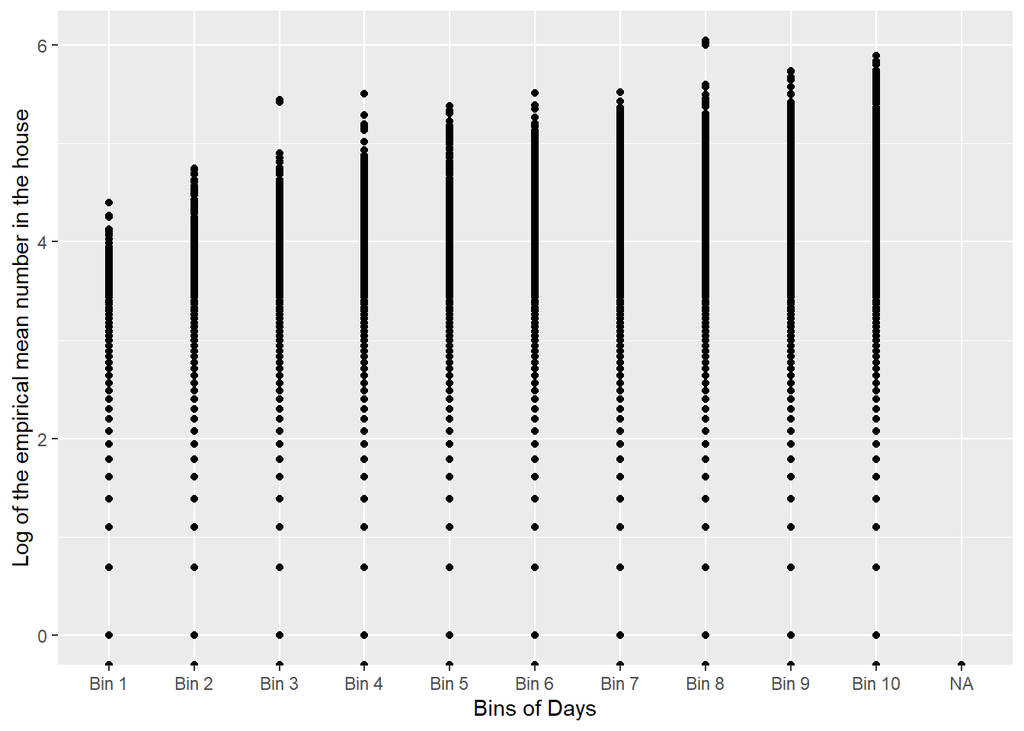

```r
ggplot(sumStats, aes(x = bin_days, y = logmntotal)) +
  geom_point() +
  geom_smooth(method = "loess", size = 1.5) +
  xlab("Bins of Days") +
  ylab("Log of the empirical mean number in the house")
```

```r
poisson_model <- glm(number_of_reviews ~ room_type + bathrooms + bedrooms + price +
                     review_scores_cleanliness + review_scores_location +
                     review_scores_value + instant_bookable + days,
                    family = poisson,
                    data = airbnb)

quasi_poisson_model <- glm(number_of_reviews ~ room_type + bathrooms + bedrooms + price +
                          review_scores_cleanliness + review_scores_location +
                          review_scores_value + instant_bookable + days,
                         family = quasipoisson,
                         data = airbnb)



summary(poisson_model)
```

```
##
## Call:
## glm(formula = number_of_reviews ~ room_type + bathrooms + bedrooms +
##     price + review_scores_cleanliness + review_scores_location +
##     review_scores_value + instant_bookable + days, family = poisson,
##     data = airbnb)
##
## Deviance Residuals:
##     Min       1Q   Median       3Q      Max
## -21.096   -4.804   -3.001    0.961   38.630
##
## Coefficients:
##                             Estimate Std. Error z value Pr(>|z|)
## (Intercept)                3.498e+00  1.609e-02 217.396  < 2e-16 ***
## room_typePrivate room     -1.054e-02  2.738e-03  -3.847 0.000119 ***
## room_typeShared room      -2.463e-01  8.620e-03 -28.578  < 2e-16 ***
## bathrooms                 -1.177e-01  3.749e-03 -31.394  < 2e-16 ***
## bedrooms                   7.409e-02  1.992e-03  37.197  < 2e-16 ***
## price                     -1.791e-05  8.327e-06  -2.151 0.031485 *
## review_scores_cleanliness  1.131e-01  1.496e-03  75.611  < 2e-16 ***
## review_scores_location    -7.690e-02  1.609e-03 -47.796  < 2e-16 ***
## review_scores_value       -9.108e-02  1.804e-03 -50.490  < 2e-16 ***
## instant_bookable           3.459e-01  2.890e-03 119.666  < 2e-16 ***
## days                       5.072e-05  3.909e-07 129.757  < 2e-16 ***
## ---
## Signif. codes:  0 '***' 0.001 '**' 0.01 '*' 0.05 '.' 0.1 ' ' 1
##
## (Dispersion parameter for poisson family taken to be 1)
##
##     Null deviance: 961626  on 30159  degrees of freedom
## Residual deviance: 926886  on 30149  degrees of freedom
##   (10468 observations deleted due to missingness)
## AIC: 1048375
##
## Number of Fisher Scoring iterations: 9
```

```r
summary(quasi_poisson_model)
```

```
##
## Call:
## glm(formula = number_of_reviews ~ room_type + bathrooms + bedrooms +
##     price + review_scores_cleanliness + review_scores_location +
##     review_scores_value + instant_bookable + days, family = quasipoisson,
##     data = airbnb)
##
## Deviance Residuals:
##     Min       1Q   Median       3Q      Max
## -21.096   -4.804   -3.001    0.961   38.630
##
## Coefficients:
##                             Estimate Std. Error t value Pr(>|t|)
## (Intercept)                3.498e+00  1.086e-01  32.211  < 2e-16 ***
## room_typePrivate room     -1.054e-02  1.848e-02  -0.570    0.569
## room_typeShared room      -2.463e-01  5.818e-02  -4.234 2.30e-05 ***
## bathrooms                 -1.177e-01  2.530e-02  -4.652 3.31e-06 ***
## bedrooms                   7.409e-02  1.344e-02   5.511 3.59e-08 ***
## price                     -1.791e-05  5.620e-05  -0.319    0.750
## review_scores_cleanliness  1.131e-01  1.010e-02  11.203  < 2e-16 ***
## review_scores_location    -7.690e-02  1.086e-02  -7.082 1.45e-12 ***
## review_scores_value       -9.108e-02  1.217e-02  -7.481 7.58e-14 ***
## instant_bookable           3.459e-01  1.951e-02  17.731  < 2e-16 ***
## days                       5.072e-05  2.638e-06  19.226  < 2e-16 ***
## ---
## Signif. codes:  0 '***' 0.001 '**' 0.01 '*' 0.05 '.' 0.1 ' ' 1
##
## (Dispersion parameter for quasipoisson family taken to be 45.54981)
##
##     Null deviance: 961626  on 30159  degrees of freedom
## Residual deviance: 926886  on 30149  degrees of freedom
##   (10468 observations deleted due to missingness)
## AIC: NA
##
## Number of Fisher Scoring iterations: 9
```

```r
exp(coef(quasi_poisson_model))
```

```
##               (Intercept)     room_typePrivate room      room_typeShared room
##                33.0509226                 0.9895192                 0.7816588
##                 bathrooms                  bedrooms                     price
##                 0.8889592                 1.0769008                 0.9999821
## review_scores_cleanliness    review_scores_location       review_scores_value
##                 1.1197873                 0.9259830                 0.9129479
##          instant_bookable                      days
##                 1.4131909                 1.0000507
```

Due to the overdispersion shown in the quasi poisson degrees of freedom we must go with the quasipoisson model. Vuong and AIC are not compareable between quasipoisson and poisson.  
Holding other variables constant, the expected rate of reviews for a private room is approximately 0.9895 times that of an entire home/apartment.  
Holding other variables constant, the expected rate of reviews for a shared room is approximately 0.7817 times that of an entire home/apartment  
Holding other variables constant, for each additional bathroom, the expected rate of reviews decreases by approximately 11.11%  
Holding other variables constant, for each additional bedroom, the expected rate of reviews increases by approximately 7.69%  
Holding other variables constant, the expected rate of reviews changes very little for a one-unit increase in price  
Holding other variables constant, for each one-unit increase in review scores cleanliness , the expected rate of reviews increase by 11%  
Holding other variables constant, for each one-unit increase in review scores location , the expected rate of reviews decreases by 8%  
Holding other variables constant, for each one-unit increase in review scores value, the expected rate of reviews decreases by 9%  
holding other variables constant, accommodations that are instant bookable have an expected rate of reviews approximately 1.41 times higher than those that are not instant bookable.  
Holding other variables constant, the expected rate of reviews increases very slightly by approximately 0.005% for each additional day.